# Harry Potter Text Mining & Sentimental Analysis

Allan Kimaina

November 2, 2017

[figure not shown]

## Background Information

Harry Potter is a series of fantasy novels written by British author J. K. Rowling. The world was introduced to Harry Potter on June 26, 1997.Twenty years later, Harry Potter and the Philosophers Stone, the first book in the series, is one of the bestselling books of all time. According to Scholastic, more than 400 million copies of Harry Potter titles have been sold worldwide, and theyâ€™ve been translated into 68 languages. For more information: [Wiki](https://en.wikipedia.org/wiki/Harry_Potter).

Harry Potter being one of the most popular novel, we though we should try do some basic yet informative frequency & sentimental analysis

## Data Sources

The text data used in this analysis was obtained from R package (harrypotter) on GitHub containing the text for all 7 books in the Harry Potter series, by JK Rowling. https://github.com/bradleyboehmke/harrypotter

We had to extract other metadata like publisher, ranking, sales, author e.t.c from https://www.theguardian.com/us

We got our hands dirty by doing some basic web scraping on https://en.wikipedia.org to extract character details.

Now let’s do some analysis!

## Quantitative and Sentimental Analysis

### Q1. Who is the most important charecter based on how much he/she was mentioned

[figure not shown]

*Fig. 1* HP

Harry being the main character in the entire series, itâ€™s clear that his name is mentioned with highest frequency. The author did a pretty nice job

### Q2. Which is the most scariest book based on sentiment analysis ?

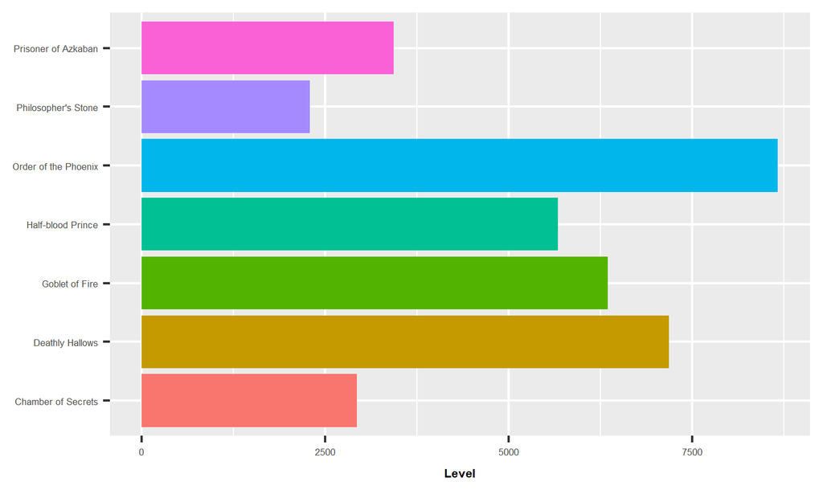

*Fig. 2* HP

Using bing lexicon, Harry Potter and the Order of the Phoenix is the scariest with about 8k negative sentiments

### Q3. What the top ten used words in exception to stop words ?

[figure not shown]

*Fig. 3* HP

| word | n |
| --- | --- |
| harry | 16717 |
| ron | 5784 |
| hermione | 4960 |
| dumbledore | 2882 |
| looked | 2344 |
| professor | 2008 |
| hagrid | 1735 |
| time | 1716 |
| wand | 1641 |
| eyes | 1610 |

### Q4. How doeas sentiment differ from one book to the next?

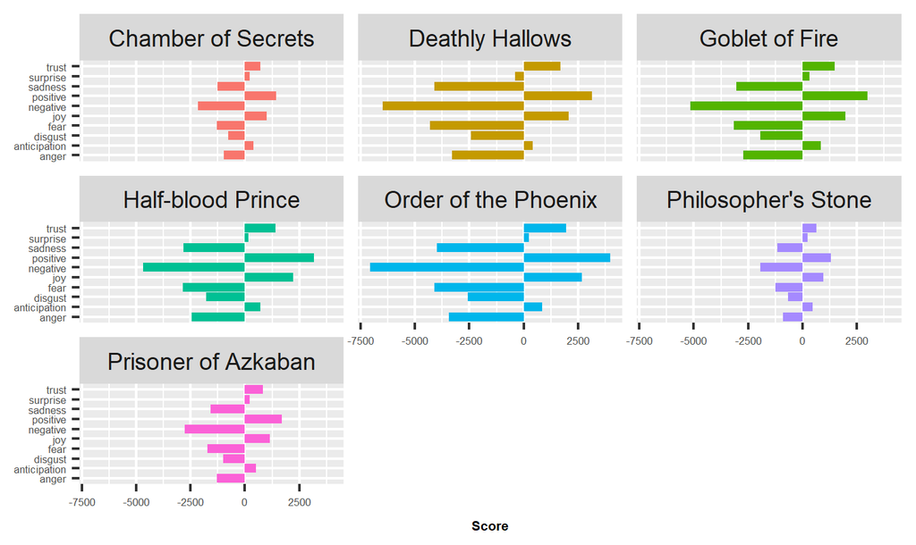

*Fig. 4* HP

### Q5. Did sentiment differences from one book to the next affected sales/popularity? Use sales metadata in www.theguardian.com

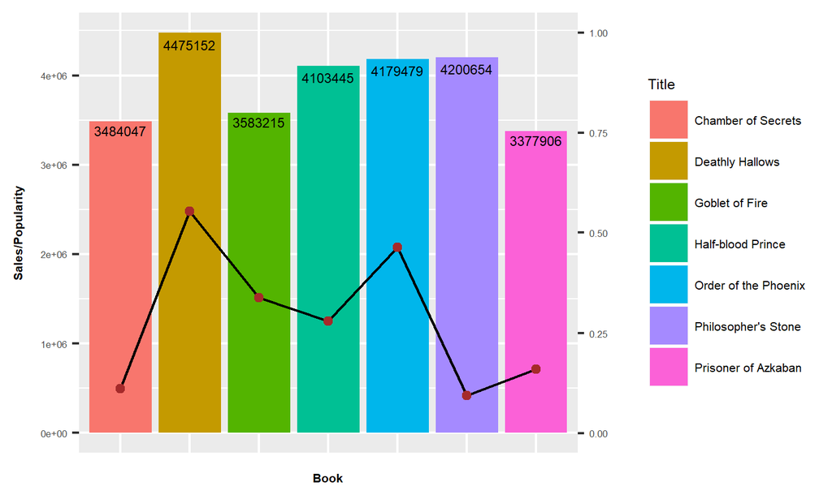

*Fig.5* HP

### Q6.How does sentiment changes from 1 chapter to the next for each book? Which book has the highest variation?

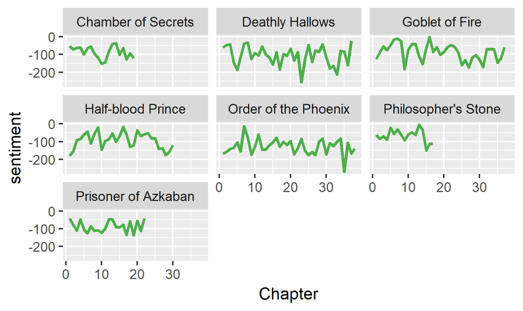

*Fig.5* HP

### Q7. Which is the most common word pairs in harry potter series? Analyze their network structure of word pairs

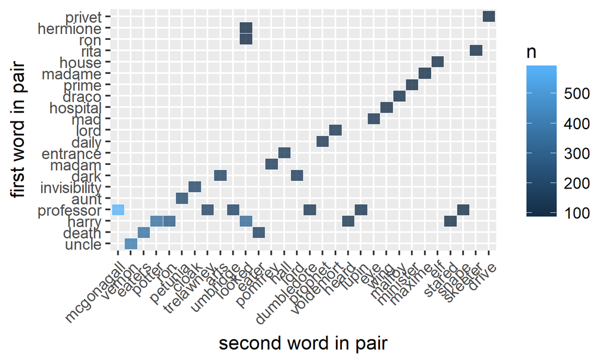

*Fig.7* HP

### Network structure of word pairs

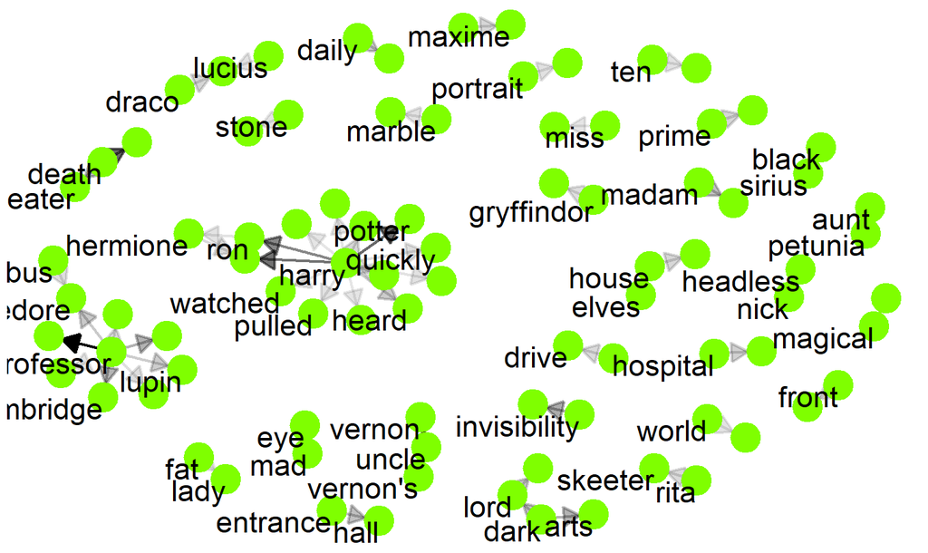

*Fig.7B* HP

### Q8.Examine how often sentiment-associated words are preceded by “not” or other negating words. How often did the writer negated clauses?

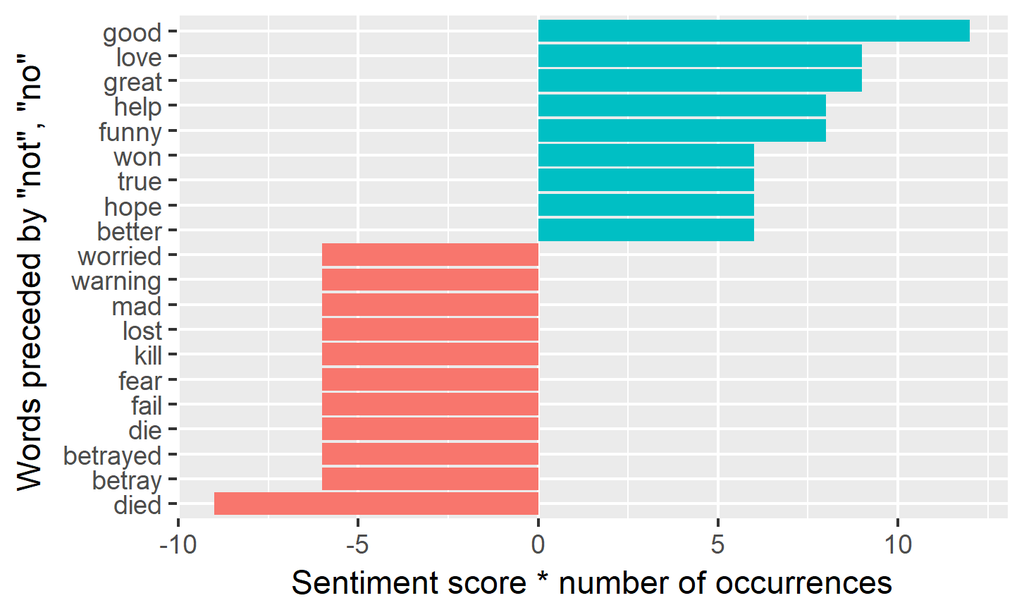

*Fig.8* HP

The author highly associated positive sentiments like “good, love, great” with negative clause. On the other hand, she assocaited highly negative sentiments like “die, betray, fail” with negative clause.